# USING LINEAR REGRESSION TO PREDICT INSURANCE CHARGES

### Sex

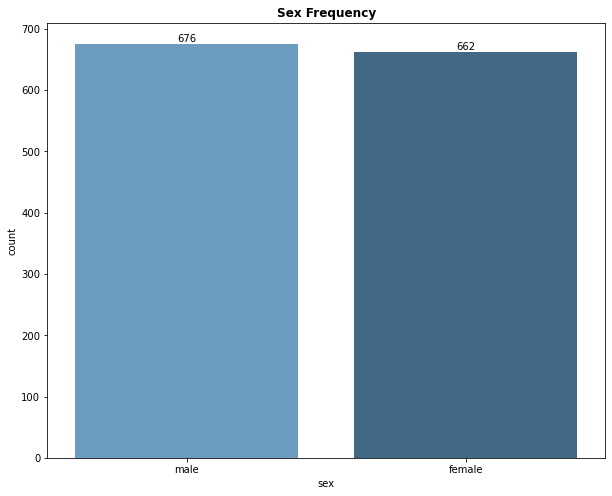

```python
plt.figure(figsize= [10, 8])
ax = sns.countplot(
    x="sex",
    data=data,
    order=data.sex.value_counts().index.values,
    palette="Blues_d",
)
ax.bar_label(ax.containers[0])
plt.title("Sex Frequency", fontweight="bold")
```

The dataset is fairly evenly distributed between men and women.

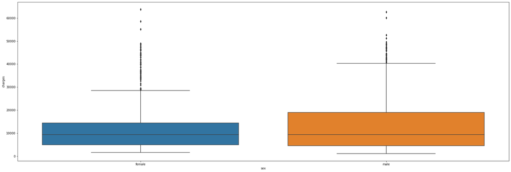

```python
plt.figure(figsize=(30,10))
sns.boxplot(data = data, x = 'sex', y = 'charges')
```

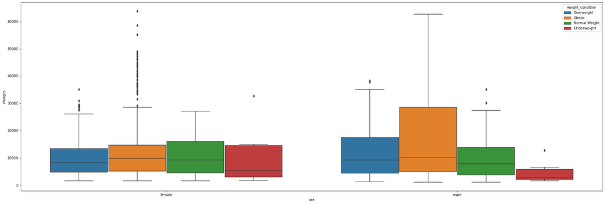

```python
plt.figure(figsize=(30,10))
sns.boxplot(data = data, x = 'sex', y = 'charges', hue = 'weight_condition')
```

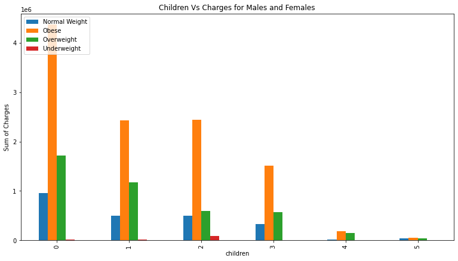

```python
df_smoker_char_age_cat=pd.crosstab(index=data.children,columns=data.weight_condition , values=data.charges,aggfunc='sum')
fig1, axes1=plt.subplots(1,1,figsize=(13, 7))
df_smoker_char_age_cat.plot(kind='bar',ax=axes1,title="Children Vs Charges for Males and Females")
plt.legend(loc='upper left')
plt.ylabel('Sum of Charges')
plt.show()
```

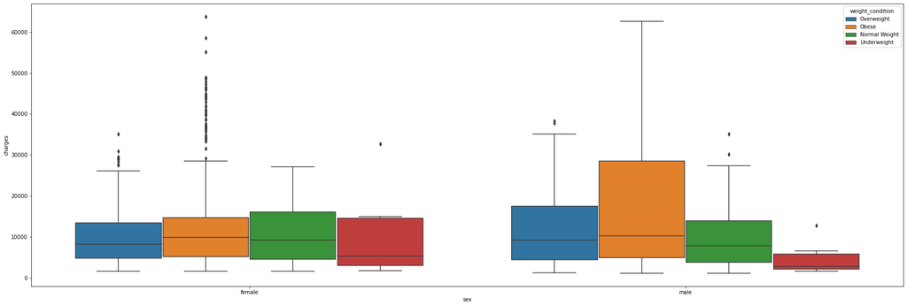

```python
plt.figure(figsize=(30,10))
sns.boxplot(data = data, x = 'sex', y = 'charges', hue = 'weight_condition')
```

The Northeast region has the highest number of people with ideal BMI, and BMIs for Overweight and Obese are also among the lowest of the four regions.

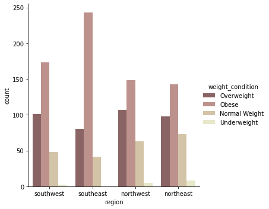

```python
ax = sns.catplot(x="region", kind="count",hue = 'weight_condition', palette="pink", data=data)
```

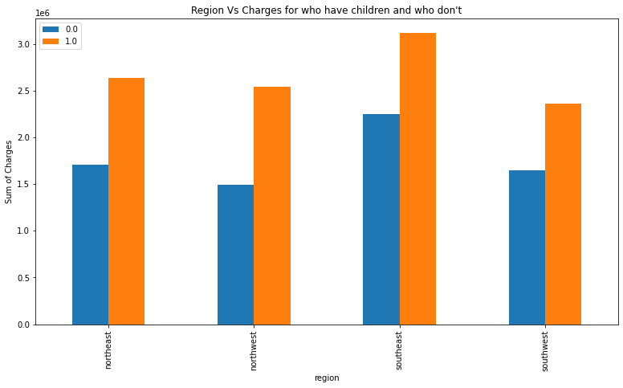

```python
df_smoker_char_age_cat=pd.crosstab(index=data.region,columns=data.have_children , values=data.charges,aggfunc='sum')
fig1, axes1=plt.subplots(1,1,figsize=(13, 7))
df_smoker_char_age_cat.plot(kind='bar',ax=axes1,title="Region Vs Charges for who have children and who don't")
plt.legend(loc='upper left')
plt.ylabel('Sum of Charges')
plt.show()
```

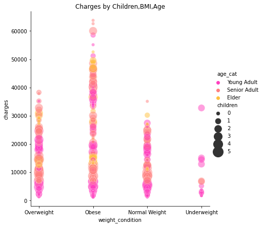

```python
sns.relplot(x=data.weight_condition, y=data.charges, hue=data.age_cat, size= data.children,
            sizes=(40, 400), alpha=.5, palette="spring",
            height=6, data=data).set(title='Charges by Children,BMI,Age')
```

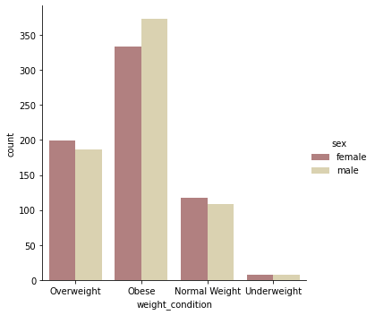

```python
ax = sns.catplot(x="weight_condition", kind="count",hue = 'sex', palette="pink", data=data)
```

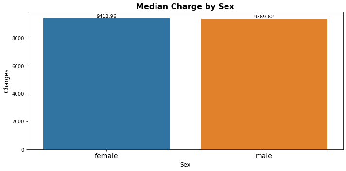

```python
plt.figure(figsize=[10, 5])
ax = sns.barplot(
    x="sex",
    y="charges",
    order=data[["sex", "charges"]]
    .groupby("sex")
    .median()
    .sort_values(by="charges", ascending=False)
    .index.values,
    ci=None,
    estimator=np.median,
    data=data,
)
ax.bar_label(ax.containers[0])
plt.title("Median Charge by Sex", fontweight="bold", fontsize=16)
plt.xticks(fontsize=14)
plt.xlabel("Sex", fontsize=12)
plt.ylabel("Charges", fontsize=12)
plt.tight_layout()
```

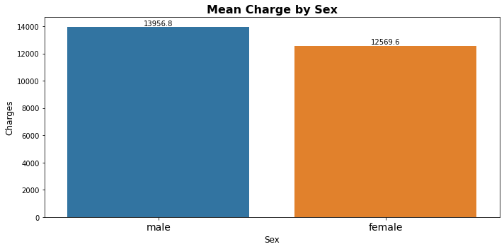

```python
plt.figure(figsize=[10, 5])
ax = sns.barplot(
    x="sex",
    y="charges",
    order=data[["sex", "charges"]]
    .groupby("sex")
    .mean()
    .sort_values(by="charges", ascending=False)
    .index.values,
    ci=None,
    estimator=np.mean,
    data=data,
)
ax.bar_label(ax.containers[0])
plt.title("Mean Charge by Sex", fontweight="bold", fontsize=16)
plt.xticks(fontsize=14)
plt.xlabel("Sex", fontsize=12)
plt.ylabel("Charges", fontsize=12)
plt.tight_layout()
```

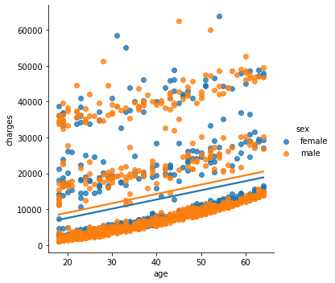

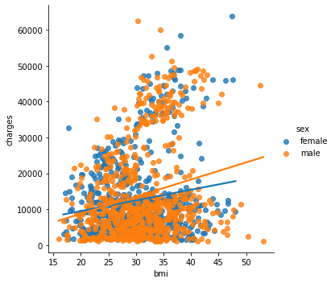

```python
sns.lmplot(x="age", y="charges", fit_reg=True, hue= 'sex', ci= None, data=data)
sns.lmplot(x="bmi", y="charges", fit_reg=True, hue= 'sex', ci= None, data=data)
```

**Figure 1:**

- The line showing the influence between *(age + sex)* on *charges* is a linear, covariate winning line.
- Both groups have the same pattern => *sex* does not affect charge by age range

**Figure 2:**

- The line showing the influence between *(bmi + sex)* on *charges* is a linear, covariate winning line.
- At the same BMI range, men will have to pay more hospital fees than women.

## Part 3 - Create model 📈

```python
def removeOutliers(df, column):
    Q3 = df[column].quantile(0.75)
    Q1 = df[column].quantile(0.25)
    IQR = Q3 - Q1
    upper = Q3 + 1.5 * IQR
    lower = Q1 - 1.5 * IQR
    return df[(df[column] > lower) & (df[column] < upper)]
```

### Feature Engineering

#### Get dummies for region

Firstly, I created 4 new columns corresponding to the value of the *region* column. I decided to use One-hot Enconding method because *region* are unordered.

```python
data = pd.read_csv('insurance.csv')
data
```

|  | age | sex | bmi | children | smoker | region | charges |
| --- | --- | --- | --- | --- | --- | --- | --- |
| 0 | 19 | female | 27.900 | 0 | yes | southwest | 16884.92400 |
| 1 | 18 | male | 33.770 | 1 | no | southeast | 1725.55230 |
| 2 | 28 | male | 33.000 | 3 | no | southeast | 4449.46200 |
| 3 | 33 | male | 22.705 | 0 | no | northwest | 21984.47061 |
| 4 | 32 | male | 28.880 | 0 | no | northwest | 3866.85520 |
| ... | ... | ... | ... | ... | ... | ... | ... |
| 1333 | 50 | male | 30.970 | 3 | no | northwest | 10600.54830 |
| 1334 | 18 | female | 31.920 | 0 | no | northeast | 2205.98080 |
| 1335 | 18 | female | 36.850 | 0 | no | southeast | 1629.83350 |
| 1336 | 21 | female | 25.800 | 0 | no | southwest | 2007.94500 |
| 1337 | 61 | female | 29.070 | 0 | yes | northwest | 29141.36030 |

1338 rows × 7 columns

```python
df_region_dumies = pd.get_dummies(data['region'])
df_region_dumies
```

|  | northeast | northwest | southeast | southwest |
| --- | --- | --- | --- | --- |
| 0 | 0 | 0 | 0 | 1 |
| 1 | 0 | 0 | 1 | 0 |
| 2 | 0 | 0 | 1 | 0 |
| 3 | 0 | 1 | 0 | 0 |
| 4 | 0 | 1 | 0 | 0 |
| ... | ... | ... | ... | ... |
| 1333 | 0 | 1 | 0 | 0 |
| 1334 | 1 | 0 | 0 | 0 |
| 1335 | 0 | 0 | 1 | 0 |
| 1336 | 0 | 0 | 0 | 1 |
| 1337 | 0 | 1 | 0 | 0 |

1338 rows × 4 columns

```python
data = pd.merge(data, df_region_dumies, left_index = True, right_index = True)
data
```

|  | age | sex | bmi | children | smoker | region | charges | northeast | northwest | southeast | southwest |
| --- | --- | --- | --- | --- | --- | --- | --- | --- | --- | --- | --- |
| 0 | 19 | female | 27.900 | 0 | yes | southwest | 16884.92400 | 0 | 0 | 0 | 1 |
| 1 | 18 | male | 33.770 | 1 | no | southeast | 1725.55230 | 0 | 0 | 1 | 0 |
| 2 | 28 | male | 33.000 | 3 | no | southeast | 4449.46200 | 0 | 0 | 1 | 0 |
| 3 | 33 | male | 22.705 | 0 | no | northwest | 21984.47061 | 0 | 1 | 0 | 0 |
| 4 | 32 | male | 28.880 | 0 | no | northwest | 3866.85520 | 0 | 1 | 0 | 0 |
| ... | ... | ... | ... | ... | ... | ... | ... | ... | ... | ... | ... |
| 1333 | 50 | male | 30.970 | 3 | no | northwest | 10600.54830 | 0 | 1 | 0 | 0 |
| 1334 | 18 | female | 31.920 | 0 | no | northeast | 2205.98080 | 1 | 0 | 0 | 0 |
| 1335 | 18 | female | 36.850 | 0 | no | southeast | 1629.83350 | 0 | 0 | 1 | 0 |
| 1336 | 21 | female | 25.800 | 0 | no | southwest | 2007.94500 | 0 | 0 | 0 | 1 |
| 1337 | 61 | female | 29.070 | 0 | yes | northwest | 29141.36030 | 0 | 1 | 0 | 0 |

1338 rows × 11 columns

```python
data.drop('region', axis = 1, inplace = True)
```

```python
data
```

|  | age | sex | bmi | children | smoker | charges | northeast | northwest | southeast | southwest |
| --- | --- | --- | --- | --- | --- | --- | --- | --- | --- | --- |
| 0 | 19 | female | 27.900 | 0 | yes | 16884.92400 | 0 | 0 | 0 | 1 |
| 1 | 18 | male | 33.770 | 1 | no | 1725.55230 | 0 | 0 | 1 | 0 |
| 2 | 28 | male | 33.000 | 3 | no | 4449.46200 | 0 | 0 | 1 | 0 |
| 3 | 33 | male | 22.705 | 0 | no | 21984.47061 | 0 | 1 | 0 | 0 |
| 4 | 32 | male | 28.880 | 0 | no | 3866.85520 | 0 | 1 | 0 | 0 |
| ... | ... | ... | ... | ... | ... | ... | ... | ... | ... | ... |
| 1333 | 50 | male | 30.970 | 3 | no | 10600.54830 | 0 | 1 | 0 | 0 |
| 1334 | 18 | female | 31.920 | 0 | no | 2205.98080 | 1 | 0 | 0 | 0 |
| 1335 | 18 | female | 36.850 | 0 | no | 1629.83350 | 0 | 0 | 1 | 0 |
| 1336 | 21 | female | 25.800 | 0 | no | 2007.94500 | 0 | 0 | 0 | 1 |
| 1337 | 61 | female | 29.070 | 0 | yes | 29141.36030 | 0 | 1 | 0 | 0 |

1338 rows × 10 columns

#### Label encoder

```python
from sklearn.preprocessing import LabelEncoder
#sex
le = LabelEncoder()
le.fit(data.sex.drop_duplicates())
data.sex = le.transform(data.sex)
# smoker or not
le.fit(data.smoker.drop_duplicates())
data.smoker = le.transform(data.smoker)
```

```python
data
```

|  | age | sex | bmi | children | smoker | charges | northeast | northwest | southeast | southwest |
| --- | --- | --- | --- | --- | --- | --- | --- | --- | --- | --- |
| 0 | 19 | 0 | 27.900 | 0 | 1 | 16884.92400 | 0 | 0 | 0 | 1 |
| 1 | 18 | 1 | 33.770 | 1 | 0 | 1725.55230 | 0 | 0 | 1 | 0 |
| 2 | 28 | 1 | 33.000 | 3 | 0 | 4449.46200 | 0 | 0 | 1 | 0 |
| 3 | 33 | 1 | 22.705 | 0 | 0 | 21984.47061 | 0 | 1 | 0 | 0 |
| 4 | 32 | 1 | 28.880 | 0 | 0 | 3866.85520 | 0 | 1 | 0 | 0 |
| ... | ... | ... | ... | ... | ... | ... | ... | ... | ... | ... |
| 1333 | 50 | 1 | 30.970 | 3 | 0 | 10600.54830 | 0 | 1 | 0 | 0 |
| 1334 | 18 | 0 | 31.920 | 0 | 0 | 2205.98080 | 1 | 0 | 0 | 0 |
| 1335 | 18 | 0 | 36.850 | 0 | 0 | 1629.83350 | 0 | 0 | 1 | 0 |
| 1336 | 21 | 0 | 25.800 | 0 | 0 | 2007.94500 | 0 | 0 | 0 | 1 |
| 1337 | 61 | 0 | 29.070 | 0 | 1 | 29141.36030 | 0 | 1 | 0 | 0 |

1338 rows × 10 columns

```python
from sklearn.preprocessing import StandardScaler, PolynomialFeatures
```

#### Remove outliers

```python
data = removeOutliers(data, 'bmi')
```

```python
for i in range(5):
    data = removeOutliers(data, 'charges')
```

```python
data.reset_index(drop = 'True', inplace = True)
```

```python
data
```

|  | age | sex | bmi | children | smoker | charges | northeast | northwest | southeast | southwest |
| --- | --- | --- | --- | --- | --- | --- | --- | --- | --- | --- |
| 0 | 19 | 0 | 27.900 | 0 | 1 | 16884.92400 | 0 | 0 | 0 | 1 |
| 1 | 18 | 1 | 33.770 | 1 | 0 | 1725.55230 | 0 | 0 | 1 | 0 |
| 2 | 28 | 1 | 33.000 | 3 | 0 | 4449.46200 | 0 | 0 | 1 | 0 |
| 3 | 33 | 1 | 22.705 | 0 | 0 | 21984.47061 | 0 | 1 | 0 | 0 |
| 4 | 32 | 1 | 28.880 | 0 | 0 | 3866.85520 | 0 | 1 | 0 | 0 |
| ... | ... | ... | ... | ... | ... | ... | ... | ... | ... | ... |
| 1105 | 52 | 0 | 44.700 | 3 | 0 | 11411.68500 | 0 | 0 | 0 | 1 |
| 1106 | 50 | 1 | 30.970 | 3 | 0 | 10600.54830 | 0 | 1 | 0 | 0 |
| 1107 | 18 | 0 | 31.920 | 0 | 0 | 2205.98080 | 1 | 0 | 0 | 0 |
| 1108 | 18 | 0 | 36.850 | 0 | 0 | 1629.83350 | 0 | 0 | 1 | 0 |
| 1109 | 21 | 0 | 25.800 | 0 | 0 | 2007.94500 | 0 | 0 | 0 | 1 |

1110 rows × 10 columns